# W3cubDocs

/D3.js 5

# d3-tile

A layout for working with image-based map tiles. This can be used to create a simple slippy map, or to render standard map tiles (*e.g.*, Mapbox, Mapzen, CloudMade, Bing) as a base layer behind a vector layer.

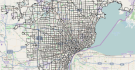

[figure not shown]

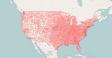

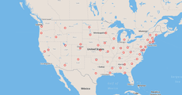

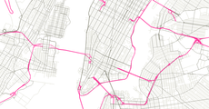

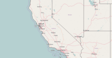

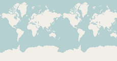

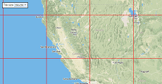

## Installing

If you use NPM, `npm install d3-tile`. Otherwise, download the [latest release](https://github.com/d3/d3-tile/releases/latest). You can also load directly from unpkg.com as a [standalone library](https://unpkg.com/d3-tile@0.0). AMD, CommonJS, and vanilla environments are supported. In vanilla, a `d3` global is exported:

```
<script src="https://unpkg.com/d3-array@1.0"></script>
<script src="https://unpkg.com/d3-tile@0.0"></script>
<script>

var tile = d3.tile();

</script>
```

[Try d3-tile in your browser.](https://tonicdev.com/npm/d3-tile)

## API Reference

###### d3.**tile**()

Constructs a layout for determining which quadtree tiles to display in a rectangular viewport.

```
var tile = d3.tile();
```

###### *tile*()

Computes the set of quadtree tiles to display given the current layout extent, scale, translate and tileSize. Returns an array of objects with the following properties:

- `x` The integer X coordinate of the tile address. Periodic if wrap is set to *true*.
- `y` The integer Y coordinate of the tile address.
- `z` The integer Z coordinate of the tile address (zoom level).
- `tx` The X translate to be applied to the tile. This is the `x` value multiplied by tileSize, but without wrapping logic applied.
- `ty` The Y translate to be applied to the tile. This is the `y` value multiplied by tileSize.

The returned array also has properties `scale` and `translate` that can be used to apply the correct transformation to the group of tile images. For example usage, see [Raster & Vector III](http://bl.ocks.org/mbostock/5914438).

###### *tile*.**extent**([*extent*])

If *extent* is specified, sets this tile layout’s extent to the specified array of points [[*x0*, *y0*], [*x1*, *y1*]], where [*x0*, *y0*] is the top-left corner and [*x1*, *y1*] is the bottom-right corner, and returns this tile layout. If *extent* is not specified, returns the current layout extent.

###### *tile*.**size**([*size*])

If *size* is specified, sets this tile layout’s size to the specified two-element array of numbers [*width*, *height*] and returns this tile layout. If *size* is not specified, returns the current layout size. This is a convenience method equivalent to setting the extent to [[0, 0], [*width*, *height*]].

###### *tile*.**scale**([*scale*])

If *scale* is specified, sets this tile layout’s scale to the specified number *scale* and returns this tile layout. If *scale* is not specified, returns the current layout scale.

###### *tile*.**translate**([*translate*])

If *translate* is specified, sets this tile layout’s translate to the specified two-element array of numbers [*x*, *y*] and returns this tile layout. If *translate* is not specified, returns the current layout translate.

###### *tile*.**wrap**([*wrap*])

If *wrap* is specified, sets this tile layout’s wrapping option to the specified boolean value and returns this tile layout. If *wrap* is not specified, returns the current wrapping option, which defaults to *true*.

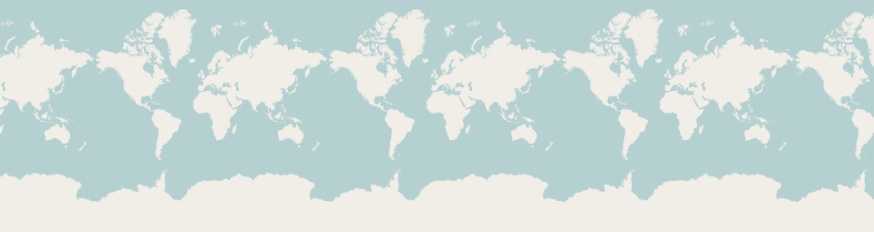

**wrap**(*true*)

If *wrap* is *true*, wrapping logic will be applied to tile address *x* values when the layout is evaluated. This will cause map tiles to be displayed in a periodic manner, going beyond longitude values between -180 and 180.

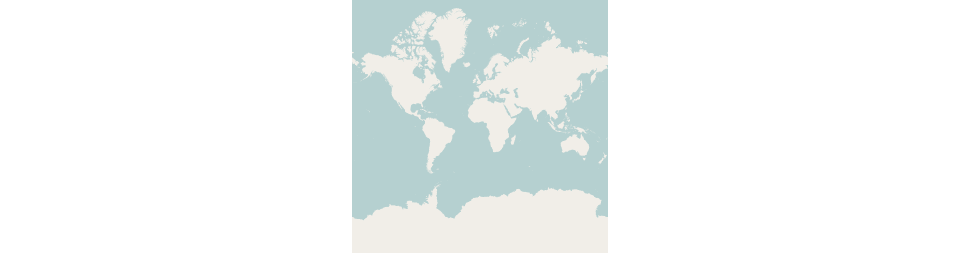

**wrap**(*false*)

If *wrap* is *false*, wrapping logic will be disabled, limiting tiles to be within longitude values between -180 and 180.

###### *tile*.**tileSize**([*tileSize*])

If *tileSize* is specified, sets this tile layout’s individual tile widths and heights to the specified number *tileSize* and returns this tile layout. If *tileSize* is not specified, returns the current layout tile size, which defaults to 256, the most common tile size among tile service providers.

© 2010–2018 Michael Bostock  
Licensed under the BSD License.  
https://github.com/d3/d3-tile